# lab04_01

## Os dados

```
attributes are not identical across measure variables; they will be dropped
```

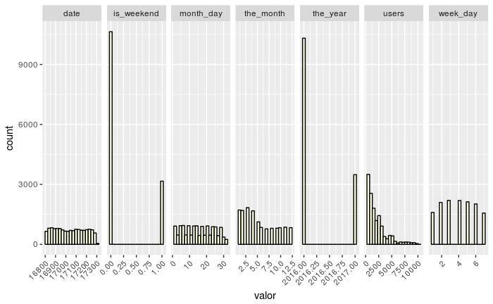

```r
github %>% gather(key = "variavel", value = "valor", -file_extension) %>%
    ggplot(aes(x = valor)) +
    theme(axis.text.x = element_text(angle = 45, hjust = 1)) +
    geom_histogram(fill = "lightyellow", color = "black", bins = 20) +
    facet_wrap(~ variavel, scales = "free_x", ncol=7)
```

Podemos perceber uma uniformidade na variável date.

Para o ano, percebemos a maior frequência no ano de 2016, o que era esperado, dado que ainda estamos pouco antes da metade de 2017.

Em relação ao mês, percebemos maior frequência nos primeiros mêses. Todavia, isso mais uma vez é devido ao fato de ainda estarmos no meio de 2017.

# As perguntas

### As duas perguntas que buscaremos responder são:

1.Para cada uma delas, há uma diferença significativa na sua popularidade durante a semana e durante o fim de semana?

2.Existe uma diferença significativa na variação da popularidade das duas quando você compara o quanto a popularidade de cada uma varia durante os dias da semana?

## Respondendo a primeira questão

### 1.Para cada uma delas, há uma diferença significativa na sua popularidade durante a semana e durante o fim de semana?

Decidimos selecionar as linguagens python e javascript.

Para responder a primeira pergunta, analisaremos a priori, separadamente, python.

Primeiramente, analisando a variável números de usuário, percembos que não há enviesamento da distribuição para python. Já para Javascript percebemos uma cauda à esquerda. Para evitar influência de possíveis outliers, utilizaremos a mediana como medida de sumarização.

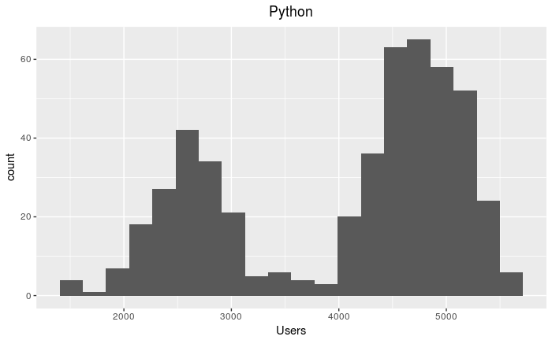

```r
py = github %>% filter(file_extension %in% c("py"))
js = github %>% filter(file_extension %in% c("js"))
py %>% ggplot(aes(x=py$users)) + geom_histogram(bins=20) + labs(x="Users") + ggtitle("Python")  + theme(plot.title = element_text(hjust = 0.5))
```

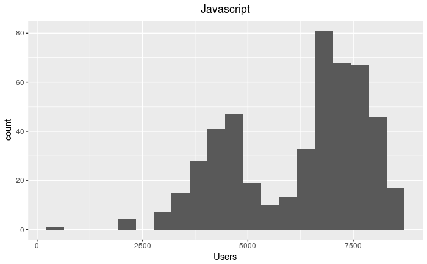

```r
js %>% ggplot(aes(x=js$users)) + geom_histogram(bins=20) + labs(x="Users") + ggtitle("Javascript") + theme(plot.title = element_text(hjust = 0.5))
```

Vamos agora realizar o bootstrap separadamente dos dois grupos(dia de semana e fim de semana) que desejamos analisar.

```
some row.names duplicated: 2 --> row.names NOT used
```

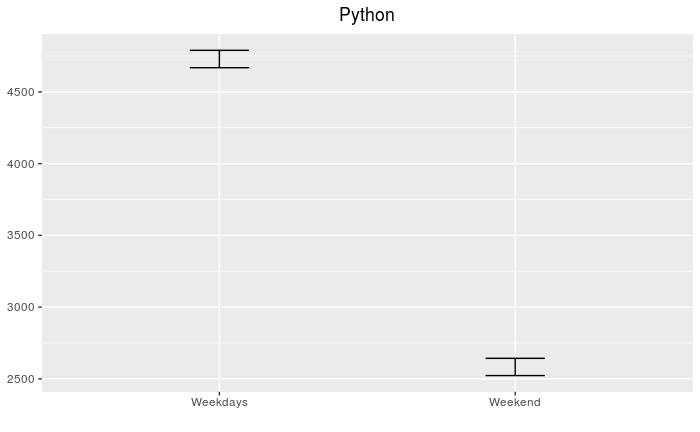

```r
#python
py_weekend = py %>% filter(is_weekend==TRUE)
py_week = py %>% filter(is_weekend==FALSE)
py_weekend_median = py_weekend$users %>% bootstrap(statistic=median)
py_week_median = py_week$users %>% bootstrap(statistic=median)
py_week_CI = CI.percentile(py_week_median, probs=c(.025, .975))
py_weekend_CI = CI.percentile(py_weekend_median, probs=c(.025, .975))
data.frame(rbind(py_week_CI, py_weekend_CI)) %>%
   ggplot(aes(x= c("Weekdays", "Weekend"), ymin = X2.5., ymax = X97.5.)) +
  geom_errorbar(width = .2) + ggtitle("Python") + theme(plot.title = element_text(hjust = 0.5)) + labs(x="")
```

```
some row.names duplicated: 2 --> row.names NOT used
```

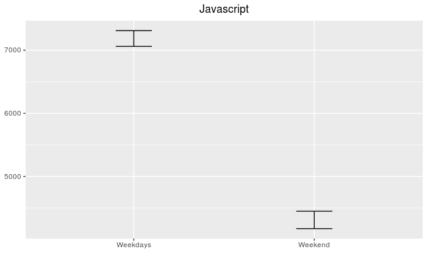

```r
#javascript
js_weekend = js %>% filter(is_weekend==TRUE)
js_week = js %>% filter(is_weekend==FALSE)
js_weekend_median = js_weekend$users %>% bootstrap(statistic=median)
js_week_median = js_week$users %>% bootstrap(statistic=median)
js_week_CI = CI.percentile(js_week_median, probs=c(.025, .975))
js_weekend_CI = CI.percentile(js_weekend_median, probs=c(.025, .975))
data.frame(rbind(js_week_CI, js_weekend_CI)) %>%
   ggplot(aes(x= c("Weekdays", "Weekend"), ymin = X2.5., ymax = X97.5.)) +
  geom_errorbar(width = .2) + ggtitle("Javascript") + theme(plot.title = element_text(hjust = 0.5)) + labs(x="")
```

```r
NA
NA
```

Com as visualizações acima, podemos afirmar que, com 95% de confiança, tanto para Python, quanto para Javascript **HÁ** uma diferença significativa em sua respectiva popularidade durante a semana e fim de semana, dado que os intervalos não se sobrepõem em nenhum dos casos.

Toda via, a análise feita acima é boa para distinguir se há ou não significativa diferença entre a popularidade da linguagem no fim de semana e dia de semana ( e foi verificado que há), mas não para ter ideia de quão diferente é.

Para sabermos mensurar a diferença, usaremos a diferença da mediana das amostras (dia de semana, e fim de semana) a cada iteração do bootstrap.

Para tal, faremos:

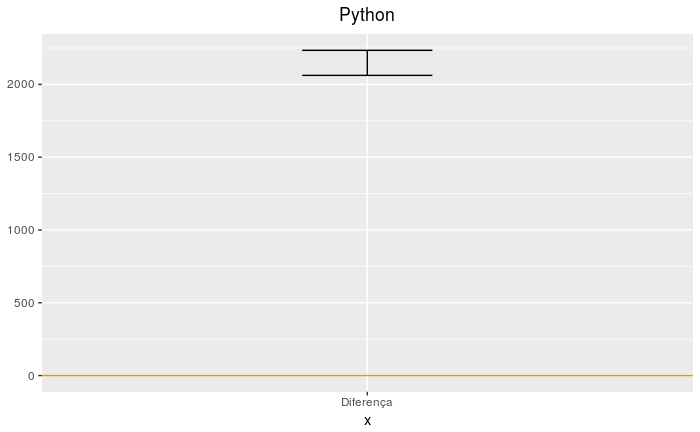

```r
py_diff_median = py$users %>% bootstrap2(statistic=median,
                                         treatment=py$is_weekend)
py_diff_CI = CI.percentile(py_diff_median, probs=c(.025, .975))
data.frame(py_diff_CI) %>%
   ggplot(aes(x= "Diferença", ymin = X2.5., ymax = X97.5.)) +
   geom_errorbar(width = .2) + ggtitle("Python") + theme(plot.title = element_text(hjust = 0.5)) +
   geom_hline(yintercept = 0, colour = "darkorange")
```

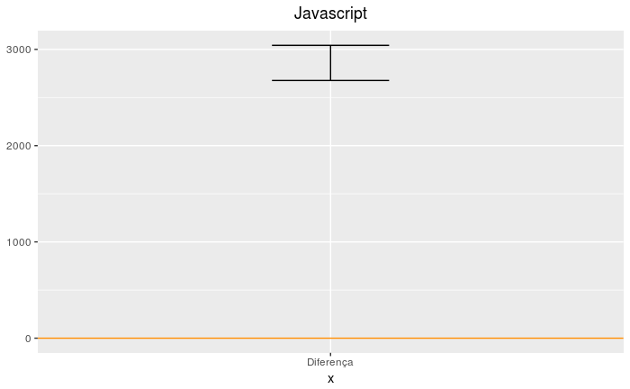

```r
#javascript
js_diff_median = js$users %>% bootstrap2(statistic=median,
                                         treatment=js$is_weekend)
js_diff_CI = CI.percentile(js_diff_median, probs=c(.025, .975))
data.frame(js_diff_CI) %>%
   ggplot(aes(x= "Diferença", ymin = X2.5., ymax = X97.5.)) +
   geom_errorbar(width = .2) + ggtitle("Javascript") + theme(plot.title = element_text(hjust = 0.5))+
   geom_hline(yintercept = 0, colour = "darkorange")
```

Observando os intervalos acima, podemos agora afirmar e verificar o quão diferente é a diferença da popularidade das linguagens em dias de semana vs fim de semana.

Podemos ainda afirmar que nos dois casos a popularidade da linguagem é maior durante os dias de semana, e com 95% de confiança podemos afirmar que está no intervalo de:

Para Javascript : [2677, 3042].

Para Python : [2062, 2234].

# Respondendo a segunda pergunta

## 2.Existe uma diferença significativa na variação da popularidade das duas quando você compara o quanto a popularidade de cada uma varia durante os dias da semana?

Para responder tal pergunta, necessitamos dos dados das linguagens python e javascript.

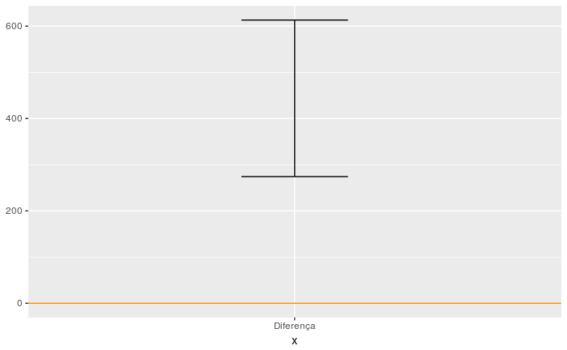